# Biomass Within Fire Perimeters — EDA

ctrees vs. eMapR within MTBS fire polygons | California wildfire cohorts

Published

July 21, 2026

This document explores aboveground biomass (AGB) **within MTBS fire perimeters** for California fires that ignited in 2005–2010. It compares two biomass datasets — **ctrees** (annual, ML-based) and **eMapR** (annual, LandTrendR-based) — using per-fire mean AGB extracted directly from raster and tabular data. No Google Earth Engine extraction is required; all data are local.

```r
# =============================================================================
# SCRIPT OUTLINE
# 1.  Setup — packages, study parameters (from params$study_year_min/max), paths, theme
# 2.  Study fire cohort — MTBS perimeters for STUDY_YEARS CA fires; map + table
# 3.  Biomass within fires — ctrees (load CSV, distributions, trend by year)
# 4.  Biomass within fires — eMapR (extract from ~100 m TIFs, cache to CSV)
# 5.  Dataset comparison — distributions, scatter, summary table
# 6.  Before / after fire event study (EDA_PLAN §4.2)
# 7.  Design notes — data limitations and implications
# =============================================================================
```

## 1. Setup

```r
library(terra)
library(sf)
library(here)
library(dplyr)
library(tidyr)
library(readr)
library(ggplot2)
library(scales)
library(glue)
library(patchwork)
library(tigris)
library(lubridate)
library(ggspatial)
library(knitr)
library(stringr)
library(RColorBrewer)
library(viridis)
library(plotly)

sf_use_s2(FALSE)
options(tigris_use_cache = TRUE, knitr.kable.NA = "—")
here::i_am("analysis/05_biomass_within_fires.qmd")

# ── Study parameters ──────────────────────────────────────────────────────────
STUDY_YEARS <- as.integer(seq(params$study_year_min, params$study_year_max))
STATE_FIPS  <- "CA"

cat("Study cohort years:", params$study_year_min, "–", params$study_year_max,
    "(", length(STUDY_YEARS), "cohorts )\n")
```

```
Study cohort years: 2005 – 2010 ( 6 cohorts )
```

```r
# ── Paths ─────────────────────────────────────────────────────────────────────
MTBS_PATH       <- here("data", "raw", "mtbs", "mtbs_perimeter_data", "mtbs_perims_DD.shp")
EMAPR_DIR       <- here("data", "processed", "emapr_biomass_ca")
CTREES_FIRE_CSV <- here("data", "processed", "ctrees",
                        "biomass_fire_polygons_ctrees_forested.csv")

# Cache keyed by cohort year range — "2000_2015" instead of listing all 16 years.
years_hash     <- paste(params$study_year_min, params$study_year_max, sep = "_")
EMAPR_FIRE_CSV <- here("data", "processed", "emapr_biomass_ca",
                       glue("biomass_fire_polygons_emapr_{years_hash}_100m_forested.csv"))

dir.create(here("figures"), showWarnings = FALSE)

# Detect all 30 m CA-clipped source TIFs (1990–2015 currently on disk).
# These determine which years can be extracted.
# ~100 m versions (~55 MB each, fact=3 from 30 m) are used for extraction —
# run scripts/r/01_create_emapr_100m_tifs.R once to generate them.
emapr_src_tifs <- list.files(EMAPR_DIR, pattern = "^composite_\\d{4}_ca\\.tif$",
                             full.names = FALSE)
EMAPR_YEARS    <- sort(as.integer(str_extract(emapr_src_tifs, "\\d{4}")))
cat("eMapR CA source TIFs (30 m) available for:", paste(EMAPR_YEARS, collapse = ", "), "\n")
```

```
eMapR CA source TIFs (30 m) available for: 1990, 1991, 1992, 1993, 1994, 1995, 1996, 1997, 1998, 2000, 2001, 2002, 2003, 2004, 2005, 2006, 2007, 2008, 2009, 2010, 2011, 2012, 2013, 2014, 2015
```

```r
# ── CA boundary ───────────────────────────────────────────────────────────────
ca_sf   <- tigris::states(cb = TRUE, year = 2022, resolution = "5m") |>
  dplyr::filter(STUSPS == STATE_FIPS)
stopifnot("State boundary not found" = nrow(ca_sf) == 1)

ca_5070 <- sf::st_transform(ca_sf, 5070)

# ── Shared ggplot theme ───────────────────────────────────────────────────────
theme_baci <- theme_minimal(base_size = 12) +
  theme(
    plot.title       = element_text(face = "bold", size = 14),
    plot.subtitle    = element_text(color = "grey40", size = 11),
    plot.caption     = element_text(color = "grey50", size = 9),
    panel.grid.minor = element_blank(),
    axis.text        = element_text(size = 10)
  )

# ── Cohort colors — viridis gradient, works for any number of study years ─────
COHORT_COLORS <- setNames(
  viridis::viridis(length(STUDY_YEARS), option = "D"),
  as.character(STUDY_YEARS)
)
```

## 2. Study Fire Cohort — MTBS Perimeters

```r
# ── Load and filter MTBS to study fires ──────────────────────────────────────
mtbs_raw <- sf::st_read(MTBS_PATH, quiet = TRUE)
cat("Total MTBS fires loaded:        ", nrow(mtbs_raw), "\n")
```

```
Total MTBS fires loaded:         30390
```

```r
mtbs_wf <- mtbs_raw |>
  dplyr::filter(incid_type == "Wildfire")
cat("After Wildfire filter:          ", nrow(mtbs_wf), "\n")
```

```
After Wildfire filter:           16446
```

```r
mtbs_study_all <- mtbs_wf |>
  dplyr::mutate(year = lubridate::year(ig_date)) |>
  dplyr::filter(year %in% STUDY_YEARS)
cat("After study-year filter:        ", nrow(mtbs_study_all), "\n")
```

```
After study-year filter:         3043
```

```r
mtbs_study <- mtbs_study_all |>
  sf::st_transform(5070) |>
  sf::st_filter(ca_5070) |>
  # Keep only fires whose MTBS event_id starts with the study state code.
  # sf::st_filter() uses perimeter intersection, so border fires from adjacent
  # states (e.g. AZ, NV) that clip into CA are included geometrically but are
  # not CA fires — drop them here.
  dplyr::filter(startsWith(event_id, STATE_FIPS)) |>
  dplyr::filter(burnbndac >= 1000) |>
  dplyr::mutate(
    asmnt_cat = dplyr::case_when(
      grepl("Extended",  asmnt_type) ~ "Extended",
      grepl("Initial",   asmnt_type) ~ "Initial",
      grepl("Emergency", asmnt_type) ~ "Emergency",
      TRUE                           ~ "Other"
    )
  )
cat("After CA spatial filter + 1000ac:", nrow(mtbs_study), "fires\n")
```

```
After CA spatial filter + 1000ac: 304 fires
```

```r
# Geometry validity check
invalid <- sum(!sf::st_is_valid(mtbs_study))
if (invalid > 0) {
  warning(glue("{invalid} invalid geometries — fixing with st_make_valid()"))
  mtbs_study <- sf::st_make_valid(mtbs_study)
}

# No duplicate event_ids
stopifnot("Duplicate event_ids found" = !any(duplicated(mtbs_study$event_id)))
cat("Total burned area:               ",
    scales::comma(round(sum(mtbs_study$burnbndac))), "acres\n")
```

```
Total burned area:                3,704,185 acres
```

### 2.1 Map of Study Fires

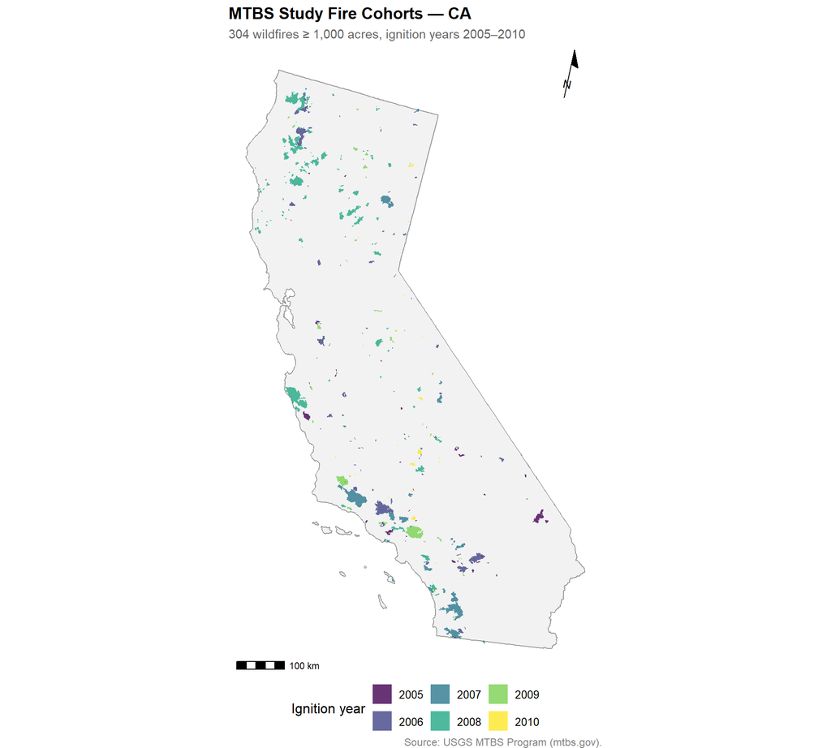

```r
# CA boundary as path for overlay
ca_path_5070 <- sf::st_coordinates(sf::st_cast(ca_5070, "MULTILINESTRING")) |>
  as.data.frame() |>
  dplyr::mutate(grp = paste(L1, L2, sep = "_"))

ggplot() +
  geom_sf(data = ca_5070, fill = "grey95", color = "grey60", linewidth = 0.4) +
  geom_sf(data = mtbs_study,
          aes(fill = factor(year)), color = NA, alpha = 0.80) +
  scale_fill_manual(
    values = COHORT_COLORS,
    name   = "Ignition year"
  ) +
  annotation_scale(location = "bl", width_hint = 0.25) +
  annotation_north_arrow(location = "tr", which_north = "true",
                         style = north_arrow_minimal()) +
  labs(
    title    = glue("MTBS Study Fire Cohorts — {STATE_FIPS}"),
    subtitle = glue("{nrow(mtbs_study)} wildfires ≥ 1,000 acres, ignition years {min(STUDY_YEARS)}–{max(STUDY_YEARS)}"),
    caption  = "Source: USGS MTBS Program (mtbs.gov)."
  ) +
  theme_void(base_size = 12) +
  theme(
    plot.title      = element_text(face = "bold", size = 14),
    plot.subtitle   = element_text(color = "grey40", size = 11),
    plot.caption    = element_text(color = "grey50", size = 9),
    legend.position = "bottom"
  )
```

### 2.2 Study Fire Summary

```r
# ── Pivot wide: one row per year, separate columns for Extended and Initial ────
fire_summary_wide <- mtbs_study |>
  sf::st_drop_geometry() |>
  dplyr::group_by(year, asmnt_cat) |>
  dplyr::summarise(
    n_fires   = dplyr::n(),
    median_ac = round(median(burnbndac)),
    total_ac  = round(sum(burnbndac)),
    .groups   = "drop"
  ) |>
  dplyr::filter(asmnt_cat %in% c("Extended", "Initial")) |>
  tidyr::pivot_wider(
    names_from  = asmnt_cat,
    values_from = c(n_fires, median_ac, total_ac)
  ) |>
  dplyr::arrange(year)

# ── Helper: stack Extended (red) over Initial (blue) in one HTML cell ─────────
ext_col <- "#d6604d"
ini_col <- "#4393c3"

html_cell <- function(ext_val, ini_val) {
  fmt <- function(x) ifelse(is.na(x), "&mdash;", scales::comma(x))
  glue(
    '<span style="color:{ext_col}">{fmt(ext_val)}</span><br>',
    '<span style="color:{ini_col}">{fmt(ini_val)}</span>'
  )
}

# ── Collapse to 4-column table ────────────────────────────────────────────────
fire_summary_html <- fire_summary_wide |>
  dplyr::mutate(
    year      = as.character(year),
    n_fires   = html_cell(n_fires_Extended,   n_fires_Initial),
    median_ac = html_cell(median_ac_Extended, median_ac_Initial),
    total_ac  = html_cell(total_ac_Extended,  total_ac_Initial)
  ) |>
  dplyr::select(year, n_fires, median_ac, total_ac)

knitr::kable(
  fire_summary_html,
  col.names = c("Year", "N fires", "Median (ac)", "Total (ac)"),
  escape    = FALSE,
  align     = c("l", "r", "r", "r"),
  caption   = paste0(
    "Study fire cohort summary by ignition year. ",
    '<span style="color:', ext_col, '">&#9632; Extended</span>',
    " &nbsp; ",
    '<span style="color:', ini_col, '">&#9632; Initial</span>.'
  )
)
```

Study fire cohort summary by ignition year. ■ Extended ■ Initial.

| Year | N fires | Median (ac) | Total (ac) |
| --- | --- | --- | --- |
| 2005 | 13 26 | 2,260 2,237 | 31,504 202,007 |
| 2006 | 30 27 | 5,378 1,956 | 583,483 106,144 |
| 2007 | 36 13 | 5,777 2,076 | 915,804 31,650 |
| 2008 | 81 16 | 3,977 6,431 | 1,175,705 164,689 |
| 2009 | 24 13 | 3,078 2,591 | 336,605 64,718 |
| 2010 | 6 19 | 5,990 1,349 | 42,792 49,084 |

## 3. Biomass Within Fires — ctrees

ctrees AGB has already been extracted within MTBS fire perimeters and stored in `biomass_fire_polygons_ctrees.csv` (columns: `event_id`, `fire_year`, `year`, `agb_mean_mgha`). Each row is the mean AGB within one fire polygon for one observation year.

```r
# ── Load and filter to study fires ────────────────────────────────────────────
# Fall back to the non-forested CSV while the slow forested extraction is running.
# Both have identical columns (event_id, fire_year, year, agb_mean_mgha);
# the only difference is the forested version masks to NLCD 2004 forest pixels.
CTREES_NONFORESTED_CSV <- here("data", "processed", "ctrees",
                               "biomass_fire_polygons_ctrees.csv")

if (file.exists(CTREES_FIRE_CSV)) {
  ctrees_src <- CTREES_FIRE_CSV
  cat("Using forested ctrees CSV (forest-masked).\n")
} else if (file.exists(CTREES_NONFORESTED_CSV)) {
  ctrees_src <- CTREES_NONFORESTED_CSV
  message("Forested CSV not found — falling back to non-forested ctrees CSV.\n",
          "Run scripts/r/04_extract_ctrees_within_fires.R then re-render.")
} else {
  stop("No ctrees CSV found. Run scripts/r/04_extract_ctrees_within_fires.R first.")
}
```

```
Using forested ctrees CSV (forest-masked).
```

```r
ctrees_all   <- readr::read_csv(ctrees_src, show_col_types = FALSE)
ctrees_fires <- ctrees_all |>
  dplyr::filter(event_id %in% mtbs_study$event_id) |>
  dplyr::mutate(
    rel_year  = year - fire_year,
    fire_year = as.integer(fire_year)
  ) |>
  dplyr::filter(!is.na(agb_mean_mgha))

cat("Source CSV:                ", basename(ctrees_src), "\n")
```

```
Source CSV:                 biomass_fire_polygons_ctrees_forested.csv
```

```r
cat("Rows in full ctrees CSV:   ", nrow(ctrees_all), "\n")
```

```
Rows in full ctrees CSV:    7904
```

```r
cat("Rows for study fires:      ", nrow(ctrees_fires), "\n")
```

```
Rows for study fires:       7072
```

```r
cat("Fires matched to MTBS:     ",
    dplyr::n_distinct(ctrees_fires$event_id), "of", nrow(mtbs_study), "\n")
```

```
Fires matched to MTBS:      272 of 304
```

```r
cat("Observation years:         ",
    min(ctrees_fires$year), "–", max(ctrees_fires$year), "\n")
```

```
Observation years:          2000 – 2025
```

```r
cat("rel_year range:            ",
    min(ctrees_fires$rel_year), "to", max(ctrees_fires$rel_year), "\n")
```

```
rel_year range:             -10 to 20
```

```r
stopifnot("fire_year values outside STUDY_YEARS" =
            all(ctrees_fires$fire_year %in% STUDY_YEARS))
```

## 4. Biomass Within Fires — eMapR

```r
# ── Inventory available ~100 m TIFs ───────────────────────────────────────────
# ~100 m TIFs (~55 MB each, fact=3 from 30 m) must be pre-generated before
# rendering. Run scripts/r/01_create_emapr_100m_tifs.R once to create them
# for all years. These files are memory-safe for terra::extract() and match
# the ctrees native ~100 m resolution for a fair comparison.
tifs_100m_ready <- sort(as.integer(str_extract(
  list.files(EMAPR_DIR, pattern = "^composite_\\d{4}_ca_100m\\.tif$"),
  "\\d{4}"
)))
cat("~100 m TIFs available for:", paste(tifs_100m_ready, collapse = ", "), "\n")
```

```
~100 m TIFs available for: 1990, 1991, 1992, 1993, 1994, 1995, 1996, 1997, 1998, 2000, 2001, 2002, 2003, 2004, 2005, 2006, 2007, 2008, 2009, 2010, 2011, 2012, 2013, 2014, 2015
```

```r
missing_100m <- setdiff(EMAPR_YEARS, tifs_100m_ready)
if (length(missing_100m) > 0) {
  message(
    length(missing_100m), " year(s) have no ~100 m TIF yet and will be skipped: ",
    paste(missing_100m, collapse = ", "),
    "\nRun scripts/r/01_create_emapr_100m_tifs.R to generate them."
  )
}
```

```r
# ── Load from pre-built cache only ────────────────────────────────────────────
# Extraction runs in scripts/r/02_extract_emapr_within_fires.R (run once in
# the R console before rendering). Doing terra::extract() inside Quarto causes
# invisible hangs on Windows because Quarto buffers chunk output and terra's
# internal C++ threading can deadlock.
EMAPR_AVAILABLE <- file.exists(EMAPR_FIRE_CSV)

if (!EMAPR_AVAILABLE) {
  message("eMapR cache not found (", basename(EMAPR_FIRE_CSV), ").\n",
          "Run scripts/r/02_extract_emapr_within_fires.R to enable eMapR sections.\n",
          "Continuing with ctrees only.")
  emapr_fires <- dplyr::tibble(event_id = character(), fire_year = integer(),
                               year = integer(), agb_mean_mgha = double(),
                               rel_year = integer())
} else {
  emapr_raw    <- readr::read_csv(EMAPR_FIRE_CSV, show_col_types = FALSE)
  cached_years <- sort(unique(emapr_raw$year))
  stale_years  <- setdiff(tifs_100m_ready, cached_years)

  if (length(stale_years) > 0) {
    message(length(stale_years), " year(s) available in TIFs but not cached: ",
            paste(stale_years, collapse = ", "),
            "\nDelete cache and re-run 02_extract_emapr_within_fires.R to refresh.")
  }

  cat("Cache loaded —", length(cached_years), "years,", nrow(emapr_raw), "rows.\n")
  cat("Cache file:", basename(EMAPR_FIRE_CSV), "\n")

  fire_meta <- sf::st_drop_geometry(mtbs_study) |>
    dplyr::select(event_id, fire_year = year)

  emapr_fires <- emapr_raw |>
    dplyr::left_join(fire_meta, by = "event_id") |>
    dplyr::mutate(
      rel_year  = year - fire_year,
      fire_year = as.integer(fire_year)
    ) |>
    dplyr::filter(!is.na(agb_mean_mgha))

  cat("eMapR rows for study fires:    ", nrow(emapr_fires), "\n")
  cat("Fires with eMapR data:         ",
      dplyr::n_distinct(emapr_fires$event_id), "of", nrow(mtbs_study), "\n")
  cat("Observation years:             ",
      min(emapr_fires$year), "–", max(emapr_fires$year), "\n")
  cat("rel_year range:                ",
      min(emapr_fires$rel_year), "to", max(emapr_fires$rel_year), "\n")
}
```

```
Cache loaded — 25 years, 7600 rows.
Cache file: biomass_fire_polygons_emapr_2005_2010_100m_forested.csv
eMapR rows for study fires:     5850
Fires with eMapR data:          234 of 304
Observation years:              1990 – 2015
rel_year range:                 -20 to 10
```

### 4.1 Mean Annual AGB — ctrees vs. eMapR

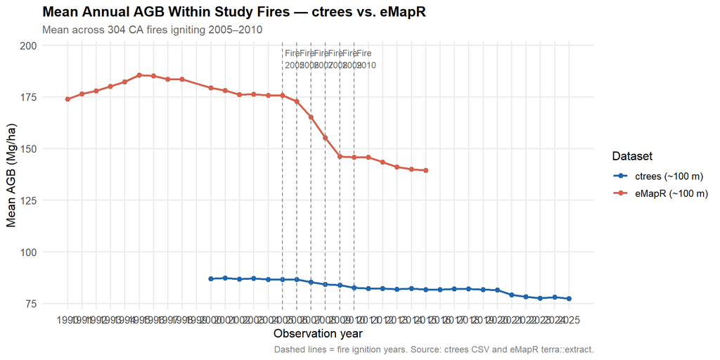

```r
# ── Pool mean AGB across all study fires per year, one line per dataset ───────
# Both ctrees_fires and emapr_fires are defined; this chunk runs after emapr-extract
combined_yr <- dplyr::bind_rows(
  ctrees_fires |>
    dplyr::group_by(year) |>
    dplyr::summarise(mean_agb = mean(agb_mean_mgha, na.rm = TRUE), .groups = "drop") |>
    dplyr::mutate(dataset = "ctrees (~100 m)"),
  emapr_fires |>
    dplyr::group_by(year) |>
    dplyr::summarise(mean_agb = mean(agb_mean_mgha, na.rm = TRUE), .groups = "drop") |>
    dplyr::mutate(dataset = "eMapR (~100 m)")
)

ggplot(combined_yr, aes(x = year, y = mean_agb, color = dataset)) +
  geom_line(linewidth = 0.9) +
  geom_point(size = 2) +
  geom_vline(xintercept = STUDY_YEARS, linetype = "dashed",
             color = "grey50", linewidth = 0.5) +
  annotate("text", x = STUDY_YEARS + 0.2, y = Inf,
           label = paste0("Fire\n", STUDY_YEARS),
           vjust = 1.4, hjust = 0, size = 3, color = "grey40") +
  scale_color_manual(
    values = c("ctrees (~100 m)" = "#2166ac", "eMapR (~100 m)" = "#d6604d"),
    name   = "Dataset"
  ) +
  scale_x_continuous(breaks = seq(min(combined_yr$year), max(combined_yr$year), by = 1)) +
  scale_y_continuous(labels = scales::comma_format(),
                     expand = expansion(mult = c(0.05, 0.15))) +
  labs(
    title    = "Mean Annual AGB Within Study Fires — ctrees vs. eMapR",
    subtitle = glue("Mean across {nrow(mtbs_study)} CA fires igniting {min(STUDY_YEARS)}–{max(STUDY_YEARS)}"),
    x        = "Observation year",
    y        = "Mean AGB (Mg/ha)",
    caption  = "Dashed lines = fire ignition years. Source: ctrees CSV and eMapR terra::extract."
  ) +
  theme_baci
```

## 5. Dataset Comparison — ctrees vs. eMapR

Compare the two datasets **at the fire ignition years** (`STUDY_YEARS`). This shows whether ctrees and eMapR agree on AGB at the moment of fire — the most directly relevant check for the DiD study. Both datasets must have data for a given year for it to be included.

```r
# Restrict to STUDY_YEARS (the fire ignition years) that are present in both datasets.
# Using all overlapping observation years would be decoupled from the study design
# and produce an unwieldy number of facets/rows. Filtering to STUDY_YEARS keeps
# the comparison tied to the top-level parameter.
both_years <- intersect(
  STUDY_YEARS,
  intersect(unique(ctrees_fires$year), unique(emapr_fires$year))
)
cat("Study years present in both datasets:", paste(sort(both_years), collapse = ", "), "\n")
```

```
Study years present in both datasets: 2005, 2006, 2007, 2008, 2009, 2010
```

```r
if (length(both_years) < length(STUDY_YEARS)) {
  missing <- setdiff(STUDY_YEARS, both_years)
  cat("  NOTE: no data in one or both datasets for year(s):",
      paste(missing, collapse = ", "), "\n")
}
```

### 5.1 Summary Statistics Table

```r
if (length(both_years) == 0) {
  message(
    "No study years have data in both datasets yet.\n",
    "Run scripts/r/01_create_emapr_100m_tifs.R to generate ~100 m TIFs for ",
    paste(setdiff(STUDY_YEARS, tifs_100m_ready), collapse = ", "),
    ", then re-render."
  )
} else {
  make_stats <- function(df, dataset_label) {
    df |>
      dplyr::filter(year %in% both_years) |>
      dplyr::group_by(year) |>
      dplyr::summarise(
        dataset  = dataset_label,
        n_fires  = dplyr::n_distinct(event_id),
        mean_agb = round(mean(agb_mean_mgha, na.rm = TRUE), 1),
        med_agb  = round(median(agb_mean_mgha, na.rm = TRUE), 1),
        sd_agb   = round(sd(agb_mean_mgha, na.rm = TRUE), 1),
        min_agb  = round(min(agb_mean_mgha, na.rm = TRUE), 1),
        max_agb  = round(max(agb_mean_mgha, na.rm = TRUE), 1),
        .groups  = "drop"
      )
  }

  stats_df <- dplyr::bind_rows(
    make_stats(ctrees_fires, "ctrees"),
    make_stats(emapr_fires,  "eMapR")
  ) |>
    dplyr::arrange(year, dataset)

  print(knitr::kable(
    stats_df,
    col.names   = c("Year", "Dataset", "N fires", "Mean (Mg/ha)", "Median",
                    "SD", "Min", "Max"),
    format.args = list(big.mark = ","),
    caption     = glue("AGB summary statistics within study fire polygons at each ",
                       "fire ignition year ({min(both_years)}–{max(both_years)}).")
  ))
}
```

```
Table: AGB summary statistics within study fire polygons at each fire ignition year (2005–2010).

|  Year|Dataset | N fires| Mean (Mg/ha)| Median|   SD|  Min|   Max|
|-----:|:-------|-------:|------------:|------:|----:|----:|-----:|
| 2,005|ctrees  |     272|         86.6|   49.2| 78.5|  3.9| 308.3|
| 2,005|eMapR   |     234|        175.7|  176.2| 74.1| 28.3| 404.1|
| 2,006|ctrees  |     272|         86.6|   48.8| 78.7|  4.5| 307.7|
| 2,006|eMapR   |     234|        172.8|  170.4| 75.2| 24.8| 397.0|
| 2,007|ctrees  |     272|         85.4|   47.1| 78.3|  2.1| 305.7|
| 2,007|eMapR   |     234|        165.2|  159.8| 76.1| 16.9| 394.8|
| 2,008|ctrees  |     272|         84.3|   46.9| 77.5|  2.0| 300.6|
| 2,008|eMapR   |     234|        155.1|  144.7| 72.0| 18.5| 384.4|
| 2,009|ctrees  |     272|         83.8|   46.7| 77.2|  2.9| 303.6|
| 2,009|eMapR   |     234|        146.1|  141.3| 67.8| 21.2| 370.8|
| 2,010|ctrees  |     272|         82.6|   45.8| 76.6|  2.9| 303.0|
| 2,010|eMapR   |     234|        145.7|  139.0| 67.1| 21.5| 368.2|
```

### 5.2 Distribution Comparison

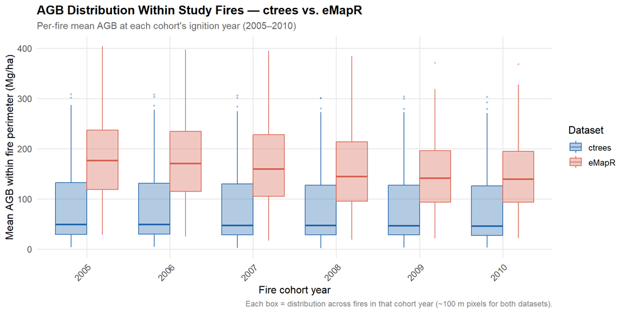

```r
if (length(both_years) == 0) {
  message("Skipping distribution plot — no overlapping study years available.")
} else {
  combined_dist <- dplyr::bind_rows(
    ctrees_fires |>
      dplyr::filter(year %in% both_years) |>
      dplyr::mutate(dataset = "ctrees"),
    emapr_fires |>
      dplyr::filter(year %in% both_years) |>
      dplyr::mutate(dataset = "eMapR")
  )

  # Boxplot by cohort year — readable for 16 years; density facets would overflow
  print(
    ggplot(combined_dist,
           aes(x = factor(year), y = agb_mean_mgha,
               fill = dataset, color = dataset)) +
      geom_boxplot(alpha = 0.35, linewidth = 0.5, outlier.size = 0.8,
                   position = position_dodge(width = 0.75)) +
      scale_fill_manual(values  = c("ctrees" = "#2166ac", "eMapR" = "#d6604d"),
                        name    = "Dataset") +
      scale_color_manual(values = c("ctrees" = "#2166ac", "eMapR" = "#d6604d"),
                         name   = "Dataset") +
      scale_y_continuous(labels = scales::comma_format()) +
      labs(
        title    = "AGB Distribution Within Study Fires — ctrees vs. eMapR",
        subtitle = glue("Per-fire mean AGB at each cohort's ignition year ({min(both_years)}–{max(both_years)})"),
        x        = "Fire cohort year",
        y        = "Mean AGB within fire perimeter (Mg/ha)",
        caption  = "Each box = distribution across fires in that cohort year (~100 m pixels for both datasets)."
      ) +
      theme_baci +
      theme(axis.text.x = element_text(angle = 45, hjust = 1))
  )
}
```

### 5.3 Scatter: ctrees vs. eMapR (per fire × year)

```
Pearson r = 0.822 | RMSE = 79.2 Mg/ha | N = 1404 fire–year pairs
```

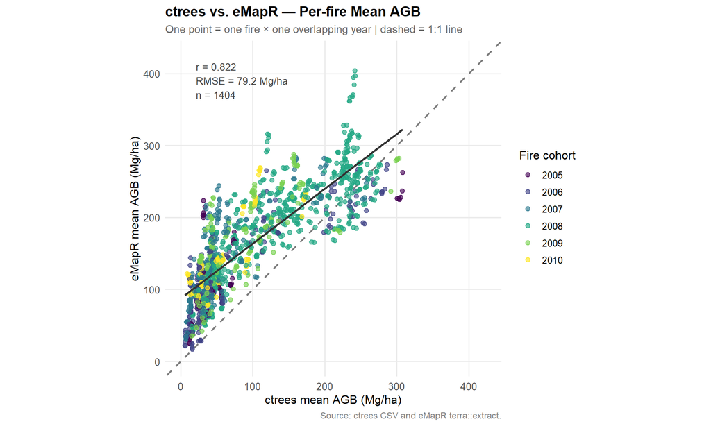

```r
if (length(both_years) == 0) {
  message("Skipping scatter plot — no overlapping study years available.")
} else {
  scatter_df <- dplyr::inner_join(
    ctrees_fires |>
      dplyr::filter(year %in% both_years) |>
      dplyr::select(event_id, year, fire_year, ctrees_agb = agb_mean_mgha),
    emapr_fires |>
      dplyr::filter(year %in% both_years) |>
      dplyr::select(event_id, year, emapr_agb = agb_mean_mgha),
    by = c("event_id", "year")
  )

  r_val  <- round(cor(scatter_df$ctrees_agb, scatter_df$emapr_agb,
                      use = "complete.obs"), 3)
  rmse   <- round(sqrt(mean((scatter_df$ctrees_agb - scatter_df$emapr_agb)^2,
                            na.rm = TRUE)), 1)
  n_pts  <- nrow(scatter_df)
  xy_max <- max(scatter_df$ctrees_agb, scatter_df$emapr_agb, na.rm = TRUE) * 1.05
  cat(glue("Pearson r = {r_val} | RMSE = {rmse} Mg/ha | N = {n_pts} fire–year pairs\n"))

  print(
    ggplot(scatter_df, aes(x = ctrees_agb, y = emapr_agb,
                           color = factor(fire_year))) +
      geom_abline(slope = 1, intercept = 0, linetype = "dashed",
                  color = "grey50", linewidth = 0.8) +
      geom_point(alpha = 0.65, size = 2) +
      geom_smooth(method = "lm", se = FALSE, linewidth = 0.9,
                  aes(group = 1), color = "grey20") +
      annotate("text", x = 0.05 * xy_max, y = 0.92 * xy_max,
               label = glue("r = {r_val}\nRMSE = {rmse} Mg/ha\nn = {n_pts}"),
               hjust = 0, size = 3.5, color = "grey25") +
      scale_color_manual(values = COHORT_COLORS, name = "Fire cohort") +
      scale_x_continuous(limits = c(0, xy_max), labels = scales::comma_format()) +
      scale_y_continuous(limits = c(0, xy_max), labels = scales::comma_format()) +
      coord_fixed() +
      labs(
        title    = "ctrees vs. eMapR — Per-fire Mean AGB",
        subtitle = "One point = one fire × one overlapping year | dashed = 1:1 line",
        x        = "ctrees mean AGB (Mg/ha)",
        y        = "eMapR mean AGB (Mg/ha)",
        caption  = "Source: ctrees CSV and eMapR terra::extract."
      ) +
      theme_baci
  )
}
```

### 5.4 Masking Progression — CA-wide, Year 2005

This section makes explicit *why* ctrees and eMapR AGB means differ so much (§5.1–5.3): part of the gap is a genuine cross-product calibration difference (visible CA-wide, independent of fires), and part is that both datasets show fires disproportionately burn lower-biomass forest. Three masking levels, both datasets, year 2005 only: (1) CA-wide raw (no mask), (2) CA-wide forest-masked (NLCD 2004), (3) forest-masked within the 2005 fire perimeters only.

```r
# ── CA boundary in both CRS, needed up front to clip the raw ctrees raster ────
ca_vect_5070 <- terra::vect(ca_5070)
ca_vect_4326 <- terra::vect(sf::st_transform(ca_5070, 4326))

# ── Load year-2005 raw rasters and forest masks (native CRS/grid per dataset) ─
ctrees_2005_raw <- terra::rast(here("data", "processed", "ctrees", "ctrees_2005_ca_100m.tif"))
emapr_2005_raw  <- terra::rast(here("data", "processed", "emapr_biomass_ca", "composite_2005_ca_100m.tif"))

# ctrees_YYYY_ca_100m.tif is only cropped to a lon/lat bounding box in
# scripts/python/03_download_ctrees_ca.py (Part C), never polygon-masked —
# unlike eMapR's composite_YYYY_ca.tif, which scripts/r/00_crop_emapr_to_ca.R
# both crops AND masks to the CA polygon. Mask here so the "raw" layer is
# actually CA-shaped, not a rectangle, for both the map and table below.
ctrees_2005_raw <- terra::mask(ctrees_2005_raw, ca_vect_4326)
```

[output not shown]

```r
ctrees_mask_raw <- terra::rast(here("data", "processed", "forest_mask", "nlcd2004_forest_100m_ca.tif"))
emapr_mask_raw  <- terra::rast(here("data", "processed", "forest_mask", "nlcd2004_forest_90m_ca.tif"))

# eMapR raw raster and its forest mask are both 90 m/EPSG:5070 but were built from
# different source rasters and have a ~30 m (1/3-pixel) origin offset — terra::mask()
# errors on mismatched extents, so resample the mask onto the raw raster's grid first
# (same fix already used per-polygon in scripts/r/02_extract_emapr_within_fires.R).
emapr_mask_2005 <- terra::resample(emapr_mask_raw, emapr_2005_raw, method = "near")
```

[output not shown]

```r
# ── Row 2: CA-wide, forest-masked ─────────────────────────────────────────────
ctrees_2005_forest <- terra::mask(ctrees_2005_raw, ctrees_mask_raw)
```

[output not shown]

```r
emapr_2005_forest  <- terra::mask(emapr_2005_raw,  emapr_mask_2005)
```

[output not shown]

```r
# ── Row 3: within 2005 fire perimeters, forest-masked ─────────────────────────
# Masking by a SpatVector keeps the full CA extent (only pixels outside the fire
# perimeters become NA) — this is what lets the maps below "show CA" at every row.
fire2005_5070 <- mtbs_study |> dplyr::filter(year == 2005) |> terra::vect()
fire2005_4326 <- mtbs_study |> dplyr::filter(year == 2005) |> sf::st_transform(4326) |> terra::vect()

ctrees_2005_fire <- terra::mask(ctrees_2005_forest, fire2005_4326)
```

[output not shown]

```r
emapr_2005_fire  <- terra::mask(emapr_2005_forest,  fire2005_5070)
```

[output not shown]

```r
cat("Rasters built:\n")
```

```
Rasters built:
```

```r
cat("  ctrees:  raw / forest-masked / within-fire  —",
    terra::global(ctrees_2005_raw,    "notNA")[[1]], "/",
    terra::global(ctrees_2005_forest, "notNA")[[1]], "/",
    terra::global(ctrees_2005_fire,   "notNA")[[1]], "valid px\n")
```

```
  ctrees:  raw / forest-masked / within-fire  — 52753282 / 12568751 / 6620 valid px
```

```r
cat("  eMapR:   raw / forest-masked / within-fire  —",
    terra::global(emapr_2005_raw,    "notNA")[[1]], "/",
    terra::global(emapr_2005_forest, "notNA")[[1]], "/",
    terra::global(emapr_2005_fire,   "notNA")[[1]], "valid px\n")
```

```
  eMapR:   raw / forest-masked / within-fire  — 50625412 / 8447371 / 3575 valid px
```

```r
# ── Summary stats computed directly from the same rasters used in the maps ────
raster_stats <- function(r) {
  s <- terra::global(r, c("mean", "sd"), na.rm = TRUE)
  n <- terra::global(r, "notNA")[[1]]
  dplyr::tibble(n_px = n, mean_agb = round(s$mean, 1), sd_agb = round(s$sd, 1))
}

# N fires with a valid (non-NA) value at year 2005, reusing the cached per-fire
# CSVs already loaded above (ctrees_fires, emapr_fires) rather than re-extracting.
n_fires_ctrees <- ctrees_fires |> dplyr::filter(fire_year == 2005, year == 2005) |> nrow()
n_fires_emapr  <- emapr_fires  |> dplyr::filter(fire_year == 2005, year == 2005) |> nrow()

masking_table <- dplyr::bind_rows(
  dplyr::bind_cols(level = "CA-wide, raw",                                          raster_stats(ctrees_2005_raw)) |>
    dplyr::rename_with(~paste0("ctrees_", .x), -level) |>
    dplyr::bind_cols(raster_stats(emapr_2005_raw) |> dplyr::rename_with(~paste0("emapr_", .x))),
  dplyr::bind_cols(level = "CA-wide, forest-masked",                                 raster_stats(ctrees_2005_forest)) |>
    dplyr::rename_with(~paste0("ctrees_", .x), -level) |>
    dplyr::bind_cols(raster_stats(emapr_2005_forest) |> dplyr::rename_with(~paste0("emapr_", .x))),
  dplyr::bind_cols(level = as.character(glue::glue(
                      "Within 2005 fire perimeters, forest-masked ",
                      "({n_fires_ctrees} ctrees / {n_fires_emapr} eMapR fires)")),
                    raster_stats(ctrees_2005_fire)) |>
    dplyr::rename_with(~paste0("ctrees_", .x), -level) |>
    dplyr::bind_cols(raster_stats(emapr_2005_fire) |> dplyr::rename_with(~paste0("emapr_", .x)))
)

knitr::kable(
  masking_table,
  col.names = c("Level", "ctrees N px", "ctrees Mean (Mg/ha)", "ctrees SD",
                "eMapR N px", "eMapR Mean (Mg/ha)", "eMapR SD"),
  format.args = list(big.mark = ","),
  caption = "AGB masking progression, year 2005 — ctrees vs. eMapR at each masking level."
)
```

AGB masking progression, year 2005 — ctrees vs. eMapR at each masking level.

| Level | ctrees N px | ctrees Mean (Mg/ha) | ctrees SD | eMapR N px | eMapR Mean (Mg/ha) | eMapR SD |
| --- | --- | --- | --- | --- | --- | --- |
| CA-wide, raw | 52,753,282 | 45.2 | 73.2 | 50,625,412 | 59.8 | 91.5 |
| CA-wide, forest-masked | 12,568,751 | 131.0 | 100.5 | 8,447,371 | 214.7 | 92.4 |
| Within 2005 fire perimeters, forest-masked (29 ctrees / 16 eMapR fires) | 6,620 | 111.7 | 126.2 | 3,575 | 168.5 | 96.6 |

**Note**

**Row 3 is a pixel-weighted pooled mean, not an average of per-fire means**

```r
# ── Timing checkpoints throughout — only visible live when this chunk is run
# in the R console, not via Render (Quarto buffers console output on Windows
# until the whole chunk finishes).
elapsed <- function(t0) paste0(round(difftime(Sys.time(), t0, units = "secs"), 1), "s")
t_chunk <- Sys.time()

# ── Shared global color scale across all CA-wide/forest-masked map panels ────
# Sample (not full-raster quantile) from the highest-magnitude layer — CA-wide
# forest-masked eMapR — to keep this fast on a ~106M-cell raster.
t0 <- Sys.time()
agb_sample <- terra::spatSample(emapr_2005_forest, size = 500000, na.rm = TRUE, values = TRUE)
agb_sample <- unlist(agb_sample, use.names = FALSE)
agb_upper  <- round(stats::quantile(agb_sample, 0.99, na.rm = TRUE))
cat("Shared color scale: 0 –", agb_upper, "Mg/ha (99th pct of CA-wide forest-masked eMapR) (", elapsed(t0), ")\n")
```

```
Shared color scale: 0 – 487 Mg/ha (99th pct of CA-wide forest-masked eMapR) ( 19s )
```

```r
viridis_cols <- hcl.colors(100, "viridis")

# ── Dataset palette, matching §4.1/5.2/5.3/6.1/6.2 throughout this document ───
CTREES_COL <- "#2166ac"
EMAPR_COL  <- "#d6604d"

# eMapR's native EPSG:5070 (Albers Conic) renders CA visibly rotated/skewed
# relative to ctrees' native EPSG:4326 (plain lat/lon). Reproject display-only
# copies to EPSG:4326 so every map panel shares the same north-up orientation
# — the table above still uses the native-CRS objects, so stats are unaffected.
# Reprojecting a rectangular Albers extent to lat/lon inflates its bounding
# box (a warped rectangle needs a larger axis-aligned box to contain it), so
# crop to ctrees' tighter native extent afterward — otherwise the eMapR
# panels get a wider axis range than ctrees and CA renders visibly smaller.
#
# Aggregate to a coarser display resolution FIRST — bilinear-reprojecting the
# full ~100m native-resolution CA-wide raster (~100M+ cells) is by far the
# most expensive step in this chunk (unlike the analytic/sampling ops above,
# it requires real per-cell interpolation across the whole grid). At this
# figure's printed size (a ~5in-wide map panel at 300dpi covering ~800km of
# California) native 100m resolution is roughly 10x finer than the image can
# even show, so aggregating to ~800m (fact=8) first is visually lossless for
# a map panel but cuts the reproject's cell count ~64x.
t0 <- Sys.time()
emapr_2005_raw_agg    <- terra::aggregate(emapr_2005_raw,    fact = 8, fun = "mean", na.rm = TRUE)
```

[output not shown]

```r
emapr_2005_forest_agg <- terra::aggregate(emapr_2005_forest, fact = 8, fun = "mean", na.rm = TRUE)
```

[output not shown]

```r
cat("eMapR aggregate for display (", elapsed(t0), ")\n")
```

```
eMapR aggregate for display ( 5.1s )
```

```r
t0 <- Sys.time()
emapr_2005_raw_disp    <- terra::project(emapr_2005_raw_agg,    "epsg:4326", method = "bilinear") |>
  terra::crop(ctrees_2005_raw)
emapr_2005_forest_disp <- terra::project(emapr_2005_forest_agg, "epsg:4326", method = "bilinear") |>
  terra::crop(ctrees_2005_raw)
cat("eMapR reproject+crop for display (", elapsed(t0), ")\n")
```

```
eMapR reproject+crop for display ( 5.5s )
```

```r
panel <- function(r, ca_vect, title) {
  t0 <- Sys.time()
  par(mar = c(2, 2, 4, 6))
  terra::plot(terra::clamp(r, lower = 0, upper = agb_upper, values = TRUE),
              col = viridis_cols, range = c(0, agb_upper),
              main = title, plg = list(title = "AGB\n(Mg/ha)", title.cex = 0.7, cex = 0.7),
              cex.main = 0.9)
  terra::plot(ca_vect, add = TRUE, col = NA, border = "grey20", lwd = 0.6)
  cat("  panel:", title, "(", elapsed(t0), ")\n")
}

# ── Area-weighted histogram helpers ────────────────────────────────────────
# Area per bin is ESTIMATED from a random subsample of valid pixels (these
# CA-wide rasters are ~100M+ cells — see the ~106M-cell note above). Two
# full-raster operations had to be avoided, in order of discovery:
#   1. Binning: terra::as.data.frame() (pulls every pixel into R) and
#      terra::classify()+terra::zonal() (whole-raster reclassify) were both
#      too slow at this cell count. Fixed by sampling up to 500k valid
#      cells with terra::spatSample() (same trick used above for the map
#      color scale, proven fast on these rasters), then binning the small
#      sample with cut()/tapply() and scaling each bin's summed area up by
#      (total valid pixels / sample size).
#   2. Area: terra::cellSize() computed over the FULL raster (materializing
#      a 100M+-cell output layer before sampling from it) was the remaining
#      untested full-raster op. Replaced with an analytic per-cell area
#      computed only for the ~500k SAMPLED cells, from their latitude (area
#      varies with latitude only in ctrees' unprojected EPSG:4326 grid;
#      eMapR's equal-area EPSG:5070 grid has a constant per-cell area).
cell_area_ha <- function(r, cells) {
  res_deg <- terra::res(r)
  if (terra::is.lonlat(r)) {
    lat       <- terra::yFromCell(r, cells)
    m_per_deg <- 111320
    (res_deg[1] * m_per_deg * cos(lat * pi / 180)) * (res_deg[2] * m_per_deg) / 10000
  } else {
    rep(prod(res_deg) / 10000, length(cells))
  }
}

sample_agb_area <- function(r, size = 500000, exact_below = 2e6) {
  t0 <- Sys.time()
  n_valid <- terra::global(r, "notNA")[[1]]
  cat("    notNA count:", n_valid, "(", elapsed(t0), ")\n")

  t0 <- Sys.time()
  if (n_valid <= exact_below) {
    # Exact enumeration for sparse rasters (e.g. the within-fire masks,
    # where valid pixels are a tiny fraction of the full CA-wide grid
    # extent). terra::spatSample()'s random-rejection sampling can fail to
    # find enough — or ANY — valid cells when the valid fraction of the
    # full extent is this low, which is what crashed barplot() here (0
    # sampled rows -> scale = n_valid/0 -> non-finite bar heights). Exact
    # enumeration via as.data.frame(na.rm=TRUE) is a fast linear scan
    # regardless of sparsity, and safe memory-wise here specifically
    # because it only ever materializes n_valid rows (small, by
    # definition of this branch) — unlike the dense CA-wide rasters below.
    cell_df <- terra::as.data.frame(r, na.rm = TRUE, cells = TRUE)
    cat("    exact enumeration:", nrow(cell_df), "pts (", elapsed(t0), ")\n")
    cells <- cell_df$cell
    agb   <- cell_df[[2]]
    scale <- 1
  } else {
    # terra::spatSample() does not reliably return a data.frame across
    # terra versions when cells=TRUE + values=TRUE (sometimes a plain
    # matrix) — as.data.frame() guarantees $cell / positional column
    # access below works either way, instead of erroring with "$ operator
    # is invalid for atomic vectors".
    samp <- terra::spatSample(r, size = min(size, n_valid), na.rm = TRUE,
                               values = TRUE, cells = TRUE)
    samp <- as.data.frame(samp)
    cat("    spatSample:", nrow(samp), "pts (", elapsed(t0), ")\n")
    cells <- samp$cell
    agb   <- samp[[2]]
    scale <- n_valid / nrow(samp)
  }

  t0 <- Sys.time()
  area_ha <- cell_area_ha(r, cells)
  cat("    cell_area_ha (", elapsed(t0), ")\n")

  list(agb = agb, area_ha = area_ha, scale = scale)
}

# Draws one ctrees/eMapR histogram pair for a given masking level, sharing
# bin breaks across the two datasets so the x-axis is directly comparable
# within that row (each masking level gets its own breaks, independent of
# the other blocks below — raw/forest-masked/burned-area have different
# AGB ranges).
hist_panel_pair <- function(r_ctrees, r_emapr, label) {
  cat(glue("  [{label}] sampling ctrees...\n"))
  ctrees_s <- sample_agb_area(r_ctrees)
  cat(glue("  [{label}] sampling eMapR...\n"))
  emapr_s  <- sample_agb_area(r_emapr)

  hist_max <- max(ctrees_s$agb, emapr_s$agb, na.rm = TRUE)
  breaks   <- seq(0, ceiling(hist_max / 25) * 25, by = 25)

  area_by_bin <- function(s) {
    bins <- cut(s$agb, breaks = breaks, include.lowest = TRUE)
    (as.numeric(tapply(s$area_ha, bins, sum))[seq_len(length(breaks) - 1)] |>
      (\(x) ifelse(is.na(x), 0, x))()) * s$scale
  }

  par(mar = c(4, 4, 4, 2))
  barplot(area_by_bin(ctrees_s), space = 0, col = CTREES_COL, border = NA,
          names.arg = breaks[-length(breaks)], las = 2, cex.names = 0.6,
          main = glue("ctrees — {label} AGB distribution"), cex.main = 0.85,
          xlab = "AGB (Mg/ha)", ylab = "Area (ha)")
  barplot(area_by_bin(emapr_s), space = 0, col = EMAPR_COL, border = NA,
          names.arg = breaks[-length(breaks)], las = 2, cex.names = 0.6,
          main = glue("eMapR — {label} AGB distribution"), cex.main = 0.85,
          xlab = "AGB (Mg/ha)", ylab = "Area (ha)")
  cat(glue("  [{label}] histograms drawn\n"))
}

map_fig_path <- here("figures", "masking_progression_2005.png")
dir.create(here("figures"), showWarnings = FALSE)

png(map_fig_path, width = 10, height = 21, units = "in", res = 300, bg = "white")
# 6-column, 5-row layout: each map row (3 cols per panel) is immediately
# followed by its own area-weighted histogram row (3 cols per panel), except
# the final row which holds a locator map + 2 narrower histograms (2 cols).
layout(matrix(c(1,1,1,   2,2,2,
                 3,3,3,   4,4,4,
                 5,5,5,   6,6,6,
                 7,7,7,   8,8,8,
                 9,9, 10,10, 11,11), nrow = 5, byrow = TRUE),
       heights = c(1, 0.85, 1, 0.85, 0.85))

# ── Row 1: CA-wide, raw ────────────────────────────────────────────────────
panel(ctrees_2005_raw,       ca_vect_4326, "ctrees — CA-wide (raw)")
```

[output not shown]

```
  panel: ctrees — CA-wide (raw) ( 11.8s )
```

```r
panel(emapr_2005_raw_disp,   ca_vect_4326, "eMapR — CA-wide (raw)")
```

```
  panel: eMapR — CA-wide (raw) ( 2s )
```

```r
# ── Row 2: CA-wide, raw — area-weighted histograms ─────────────────────────
hist_panel_pair(ctrees_2005_raw, emapr_2005_raw, "CA-wide (raw)")
```

```
[CA-wide (raw)] sampling ctrees...    notNA count: 52753282 ( 3.9s )
    spatSample: 500000 pts ( 12.7s )
    cell_area_ha ( 0s )
[CA-wide (raw)] sampling eMapR...    notNA count: 50625412 ( 2.9s )
    spatSample: 500000 pts ( 6.6s )
    cell_area_ha ( 0s )
```

```
[CA-wide (raw)] histograms drawn
```

```r
# ── Row 3: CA-wide, forest-masked ──────────────────────────────────────────
panel(ctrees_2005_forest,    ca_vect_4326, "ctrees — CA-wide (forest-masked)")
```

[output not shown]

```
  panel: ctrees — CA-wide (forest-masked) ( 7.3s )
```

```r
panel(emapr_2005_forest_disp, ca_vect_4326, "eMapR — CA-wide (forest-masked)")
```

```
  panel: eMapR — CA-wide (forest-masked) ( 0.7s )
```

```r
# ── Row 4: CA-wide, forest-masked — area-weighted histograms ──────────────
hist_panel_pair(ctrees_2005_forest, emapr_2005_forest, "CA-wide (forest-masked)")
```

```
[CA-wide (forest-masked)] sampling ctrees...    notNA count: 12568751 ( 2.6s )
```

```
    spatSample: 480031 pts ( 9.2s )
    cell_area_ha ( 0s )
[CA-wide (forest-masked)] sampling eMapR...    notNA count: 8447371 ( 2.2s )
```

```
    spatSample: 199746 pts ( 5.7s )
    cell_area_ha ( 0s )
```

```
[CA-wide (forest-masked)] histograms drawn
```

```r
# ── Row 5, panel 1: fire-polygon locator map (EPSG:4326, matches all panels) ─
t0 <- Sys.time()
par(mar = c(2, 2, 4, 2))
terra::plot(ca_vect_4326, col = "grey95", border = "grey20", lwd = 0.6,
            main = "2005 fire perimeters", cex.main = 0.9)
terra::plot(fire2005_4326, add = TRUE, col = "red", border = "darkred", lwd = 0.8)
cat("  panel: 2005 fire perimeters (", elapsed(t0), ")\n")
```

```
  panel: 2005 fire perimeters ( 0.1s )
```

```r
# ── Row 5, panels 2-3: within-fire, forest-masked — area-weighted histograms ─
hist_panel_pair(ctrees_2005_fire, emapr_2005_fire, "within-fire")
```

```
[within-fire] sampling ctrees...    notNA count: 6620 ( 2.5s )
    exact enumeration: 6620 pts ( 27.6s )
    cell_area_ha ( 0s )
[within-fire] sampling eMapR...    notNA count: 3575 ( 3.3s )
    exact enumeration: 3575 pts ( 13s )
    cell_area_ha ( 0s )
```

```
[within-fire] histograms drawn
```

```r
dev.off()
```

```r
cat("Total chunk time (", elapsed(t_chunk), ")\n")
```

```
Total chunk time ( 146s )
```

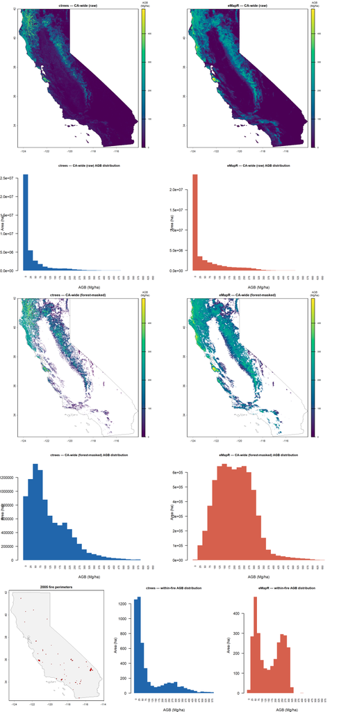

```r
knitr::include_graphics(map_fig_path)
```

## 6. Before / After Fire Event Study

This section adapts EDA_PLAN §4.2 to use actual AGB (Mg/ha) from both datasets, indexed to each fire’s ignition year (`rel_year = 0`).

```r
# ── Build combined long data frame indexed to fire year ───────────────────────
# Derived from EMAPR_YEARS/STUDY_YEARS (not hardcoded) so these bounds stay
# correct automatically if the study cohort changes. REL_MIN uses the latest
# cohort year (gives the deepest/most-negative pre-fire rel_year back to
# eMapR's earliest available year); REL_MAX uses the earliest cohort year
# (gives the longest post-fire window still covered by eMapR's most recent
# year) — matching the same eMapR-bounded logic used throughout this section.
REL_MIN <- min(EMAPR_YEARS) - max(STUDY_YEARS)
REL_MAX <- max(EMAPR_YEARS) - min(STUDY_YEARS)

event_long <- dplyr::bind_rows(
  ctrees_fires |> dplyr::mutate(dataset = "ctrees (~100 m)"),
  emapr_fires  |> dplyr::mutate(dataset = "eMapR (~100 m)")
) |>
  dplyr::filter(rel_year >= REL_MIN, rel_year <= REL_MAX)

# Aggregate: mean ± SE across fires, by dataset × rel_year
event_agg <- event_long |>
  dplyr::group_by(dataset, rel_year) |>
  dplyr::summarise(
    mean_agb = mean(agb_mean_mgha, na.rm = TRUE),
    se_agb   = sd(agb_mean_mgha,   na.rm = TRUE) / sqrt(dplyr::n()),
    n_fires  = dplyr::n_distinct(event_id),
    .groups  = "drop"
  )

cat("Event-study rows per dataset:\n")
```

```
Event-study rows per dataset:
```

```r
print(dplyr::count(event_agg, dataset))
```

```
# A tibble: 2 × 2
  dataset             n
  <chr>           <int>
1 ctrees (~100 m)    21
2 eMapR (~100 m)     31
```

### 6.1 Pooled Event Study — All Cohorts Combined

```r
n_fires_total  <- dplyr::n_distinct(event_long$event_id)

# Show the full window where data exists (REL_MIN/REL_MAX derived above from
# EMAPR_YEARS/STUDY_YEARS). eMapR bounds both edges: pre-fire it reaches back
# to 1990, post-fire it currently stops at its most recent available year;
# ctrees' own range is wider on both ends but is capped here to keep axes
# matched to eMapR. Pooling cohorts at extreme rel_years means fewer fires
# contribute — the latest cohort dominates the most-negative rel_years and
# the earliest cohort dominates the most-positive ones.
event_agg_pooled <- dplyr::filter(event_agg, rel_year >= REL_MIN, rel_year <= REL_MAX)

# Build the tooltip text on the point layer; other layers get no tooltip
p_event <- ggplot(event_agg_pooled, aes(x = rel_year, y = mean_agb,
                                 color = dataset)) +
  geom_line(linewidth = 1.0) +
  geom_point(
    aes(text = glue(
      "Dataset: {dataset}\n",
      "Rel. year: {rel_year}\n",
      "Mean AGB: {round(mean_agb, 1)} Mg/ha\n",
      "±1 SE: ±{round(se_agb, 1)} Mg/ha\n",
      "N fires: {n_fires}"
    )),
    size = 2.5
  ) +
  geom_vline(xintercept = 0, linetype = "dashed",
             color = "grey30", linewidth = 0.8) +
  scale_color_manual(
    values = c("ctrees (~100 m)" = "#2166ac", "eMapR (~100 m)" = "#d6604d"),
    name   = "Dataset"
  ) +
  scale_x_continuous(
    breaks = seq(REL_MIN, REL_MAX, by = 2),
    name   = "Years relative to fire"
  ) +
  scale_y_continuous(
    labels = scales::comma_format(),
    expand = expansion(mult = c(0.05, 0.15)),
    name   = "Mean AGB (Mg/ha)"
  ) +
  labs(
    title  = "Aboveground Biomass Before and After Fire — ctrees vs. eMapR",
    x      = "Years relative to fire",
    y      = "Mean AGB (Mg/ha)"
  ) +
  theme_baci

plotly::ggplotly(p_event, tooltip = "text") |>
  plotly::layout(
    title = list(
      text = paste0(
        "Aboveground Biomass Before and After Fire — ctrees vs. eMapR",
        "<br><sup>Mean ±1 SE across ", n_fires_total, " CA fires igniting ",
        min(STUDY_YEARS), "–", max(STUDY_YEARS),
        " | eMapR: ", min(EMAPR_YEARS), "–2015 | ctrees: 2000–2025",
        " | dashed = fire year</sup>"
      )
    )
  )
```

[interactive chart not shown]

### 6.2 Event Study by Fire Cohort

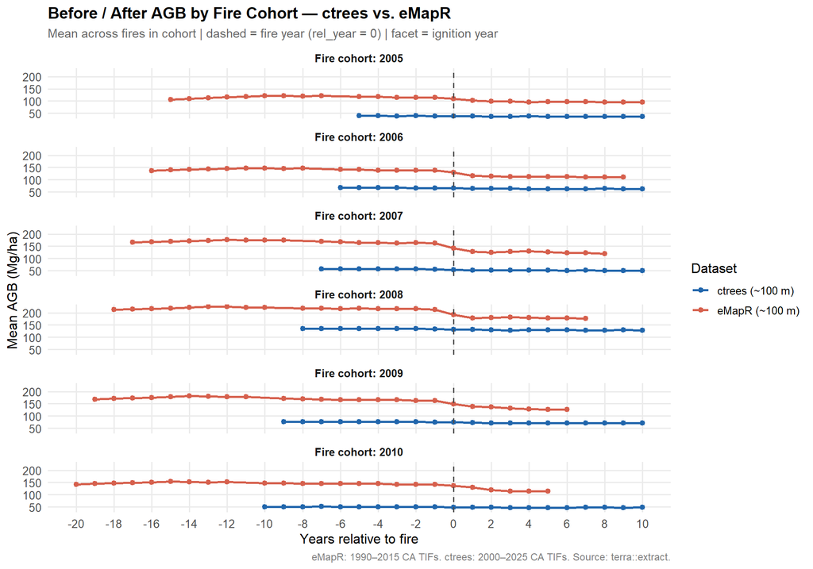

```r
# Per-cohort aggregation — use full window; each cohort's data range differs by dataset
event_agg_cohort <- event_long |>
  dplyr::group_by(dataset, fire_year, rel_year) |>
  dplyr::summarise(
    mean_agb = mean(agb_mean_mgha, na.rm = TRUE),
    se_agb   = sd(agb_mean_mgha,   na.rm = TRUE) / sqrt(dplyr::n()),
    n_fires  = dplyr::n_distinct(event_id),
    .groups  = "drop"
  )

ggplot(event_agg_cohort,
       aes(x = rel_year, y = mean_agb, color = dataset, fill = dataset)) +
  geom_line(linewidth = 0.9) +
  geom_point(size = 1.8) +
  geom_vline(xintercept = 0, linetype = "dashed",
             color = "grey30", linewidth = 0.7) +
  facet_wrap(~ fire_year, ncol = 1,
             labeller = labeller(fire_year = function(x) paste("Fire cohort:", x))) +
  scale_color_manual(
    values = c("ctrees (~100 m)" = "#2166ac", "eMapR (~100 m)" = "#d6604d"),
    name   = "Dataset"
  ) +
  scale_fill_manual(
    values = c("ctrees (~100 m)" = "#2166ac", "eMapR (~100 m)" = "#d6604d"),
    name   = "Dataset"
  ) +
  scale_x_continuous(
    breaks = seq(REL_MIN, REL_MAX, by = 2),
    name   = "Years relative to fire"
  ) +
  scale_y_continuous(
    labels = scales::comma_format(),
    name   = "Mean AGB (Mg/ha)"
  ) +
  labs(
    title    = "Before / After AGB by Fire Cohort — ctrees vs. eMapR",
    subtitle = "Mean across fires in cohort | dashed = fire year (rel_year = 0) | facet = ignition year",
    caption  = "eMapR: 1990–2015 CA TIFs. ctrees: 2000–2025 CA TIFs. Source: terra::extract."
  ) +
  theme_baci +
  theme(strip.text = element_text(face = "bold"))
```

## 7. Design Notes

**Note**

**ctrees pre-fire baseline**

ctrees data starts in 2000, providing 5 pre-fire year(s) of ctrees baseline for the earliest cohort (2005), up to 10 year(s) for the latest cohort (2010). eMapR extends back to 1990, providing up to 15 years of pre-fire baseline for the earliest cohort.

**Note**

**Important**

**Implication for DiD study design**

1. Choose whether to use ctrees (better sensor stack, limited pre-period) or eMapR (longer pre-period, Landsat-only) as the primary outcome variable.
2. Decide whether to exclude fires that have only Initial assessments if severity heterogeneity is large (see §3.6 of `04_data_summary.qmd`).